# UB3 – Tutorium Mathe A WS19/20

Maximilian Kohnen

Tutorium: 07/11/2019

# Aufgabe 1

Die Implikation soll mittels Kontraposition gelöst werden. Bei Aufstellen der Kontraposition ist wichtig zu beachten, dass:
$$A \Rightarrow B \Leftrightarrow \neg B \Rightarrow \neg A$$
Für unseren Fall heißt das also:

$$\neg(A=B) \Rightarrow \neg(A \backslash B = B \backslash A) \\
A \neq B \Rightarrow A \backslash B \neq B \backslash A$$

A und B stellen in diesem Fall Mengen dar, also beschreibt $A \backslash B$ eine Mengendifferenz.

$$A \neq B \Rightarrow \exists a \in A : a\notin B$$
$$\Rightarrow a \in A \backslash B \quad \text{und} \quad a \notin B \backslash A \quad \text{da} \quad a \notin B \\
\Rightarrow A \backslash B \neq B \backslash A \quad \quad \text{q.e.d}$$

Weiteres Material zu Mengen und Aussagen: http://www.gm.fh-koeln.de/~konen/Mathe1-WS/ZD1-Kap01-02.pdf

# Aufgabe 2

Für die Überprfung, ob die Menge M eine Gruppe darstellt, müssen die 4 Bedingungen: Abgeschlossenheit, Assoziativität, neutrales Element und inverses Element erfüllt sein.

- **Abgeschlossenheit** ($a \in G, b \in G : a \circ b \in G$):

  Die Tabelle zeigt, dass jede Kombination der Elemente der Menge M wiederrum ein Element der Menge M ergibt.

$$\begin{array}{c|c c c c}
\circ & S_{m} & S_{n} & D_{0} & D_{180} \\
\hline
S_{m} & D_{0} & D_{180} & S_{m} & S_{n} \\
S_{n} & D_{180} & D_{0} & S_{n} & S_{m} \\
D_{0} & S_{m} & S_{n} & D_{0} & D_{180} \\
D_{180} & S_{n} & S_{m} & D_{180} & D_{0} \\
\end{array}$$

- **Assoziativität** ($(b\circ a) \circ c = a \circ (b \circ c)$):

  Beispiel:

$$(S_{m} \circ D_{180}) \circ S_{n} = S_{m} \circ (D_{180} \circ S_{n})$$
$$S_{n} \circ S_{n} = S_{m} \circ S_{m}$$
$$D_{0} = D_{0}$$

- **Neutrales Element** ($\exists e \in G, \forall a \in G : a \circ e = a$): $D_{0}$

  Jedes Element der Menge M ergibt in der Kombination mit $D_{0}$ sich selbst (siehe Tabelle).
- **Inverses Element** ($\forall a \in G, \exists \bar{a} \in G: a \circ \bar{a} = e$):

  Jedes Element ist gleichzeitig sein eigenes inverses Element. Z.B.:
  $$S_{m} \circ S_{m} = D_{0}$$

$\Rightarrow$ Alle Bedingungen sind erfüllt, daher stellt **M eine Gruppe** dar.

- **Kommultativität** ($\forall a \in G, \forall b \in G: a \circ b = b \circ a$):

  Beispiel:

$$S_{m} \circ S_{n} = S_{n} \circ S_{m}$$
$$D_{180} = D_{180}$$

$\Rightarrow$ Nachdem auch die Kommultativität hier erfüllt ist, stellt M sogar eine **Abelsche Gruppe** dar.

# Aufgabe 3

1. $f(x) = 10$:

   $D = \mathbb{R}$  
   $B = \{10\}$  
   $\Rightarrow$ nicht surjektiv, nicht injektiv

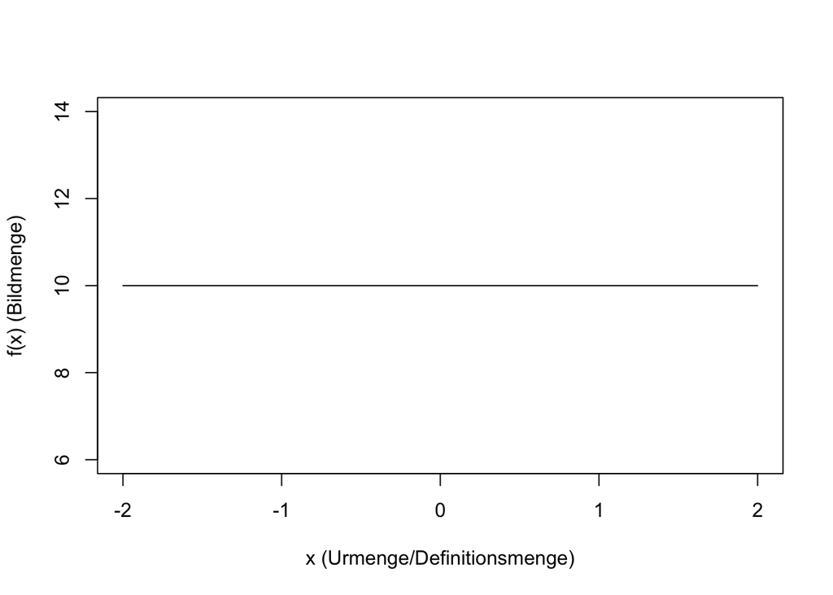

2. $f(x) = x^{2} + 2$:

   $D = \mathbb{R}$  
   $B = [2, + \infty[$  
   $\Rightarrow$ nicht surjektiv, nicht injektiv

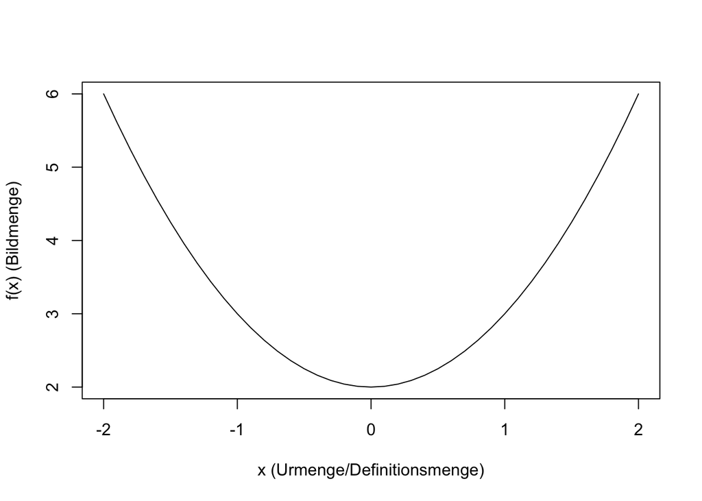

3. $f(x) = x^{3}$:

   $D = \mathbb{R}$  
   $B = \mathbb{R}$  
   $\Rightarrow$ surjektiv und injektiv $\rightarrow$ bijektiv

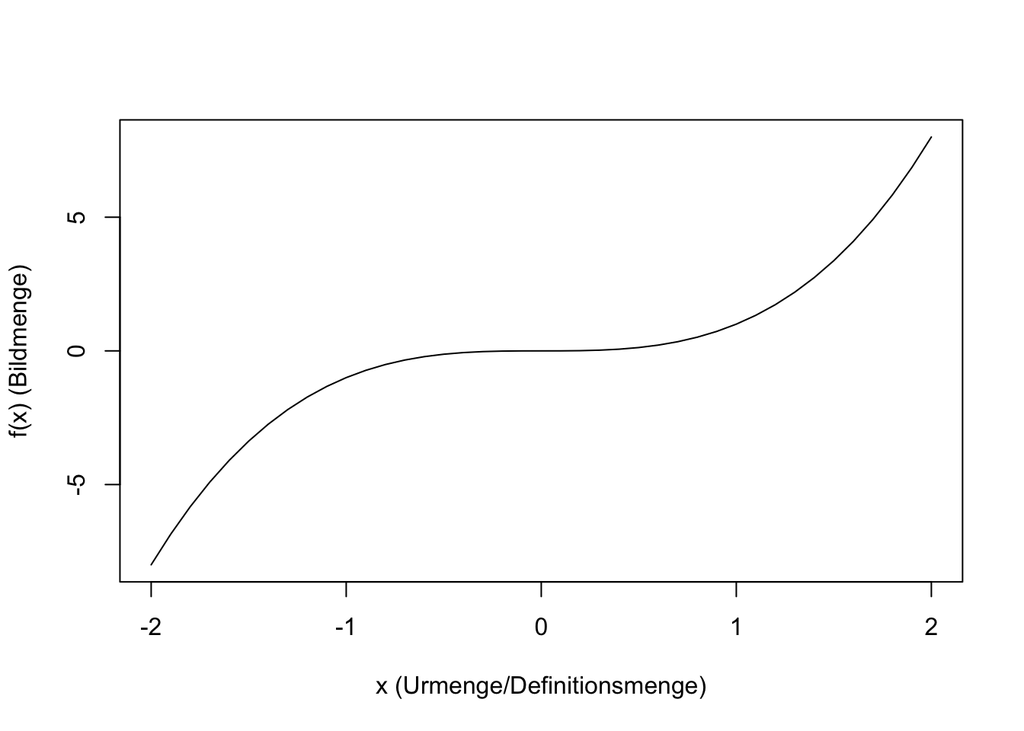

4. $f(x) = \sqrt{x}$:

   $D = \mathbb{R}^{+}$  
   $B = \mathbb{R}^{+}$  
   $\Rightarrow$ nicht surjektiv, aber injektiv

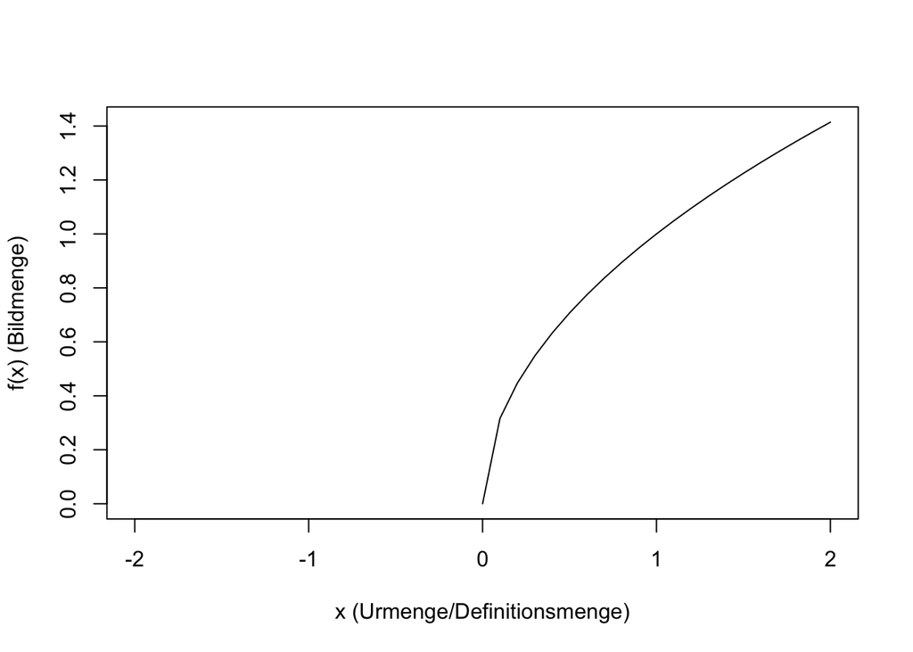

5. $f(x) = |x| - x$:

   $D = \mathbb{R}$  
   $B = \mathbb{R}^{+}$  
   $\Rightarrow$ nicht surjektiv, nicht injektiv

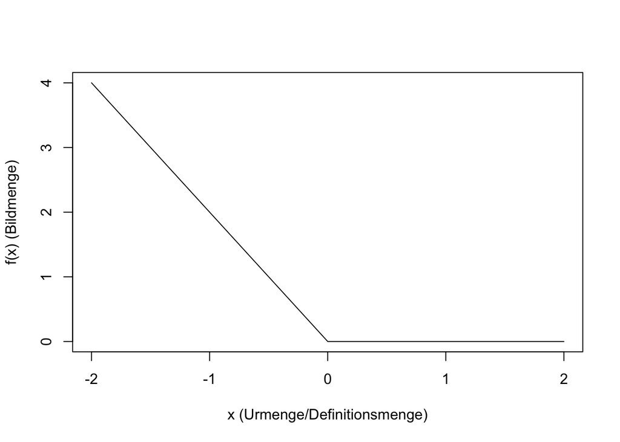

6. $f(x) = (sgn(x))^{2}$ wobei $sgn(x)=1$ wenn $x \geq 0$ und $sgn(x)=-1$ wenn $x<0$:

   $D = \mathbb{R}$  
   $B = \{1\}$  
   $\Rightarrow$ nicht surjektiv, nicht injektiv

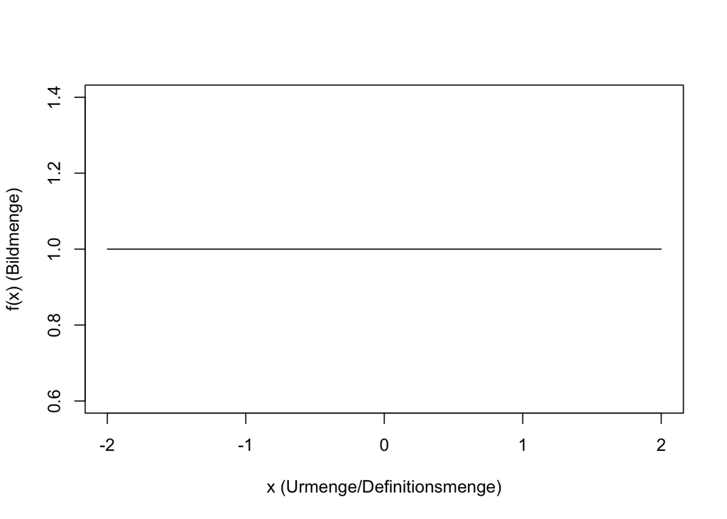

# Aufgabe 4

### Teilaufgabe a

$$\overrightarrow{a} + (\vec{b} - \vec{c}) =
\left(\begin{array}{c} 1 \\ 2 \\ -3 \end{array} \right)
+ \left( \left(\begin{array}{c} 2 \\ 1 \\ 1 \end{array} \right)
- \left(\begin{array}{c} -1 \\ 0 \\ 3 \end{array} \right) \right)
= \left(\begin{array}{c} 1 \\ 2 \\ -3 \end{array} \right)
+ \left(\begin{array}{c} 3 \\ 1 \\ -2 \end{array} \right)
= \left(\begin{array}{c} 4 \\ 3 \\ -5 \end{array} \right)$$

$$\overrightarrow{a} \cdot (\vec{b} - \vec{c}) =
\left(\begin{array}{c} 1 \\ 2 \\ -3 \end{array} \right)
\cdot \left(\begin{array}{c} 3 \\ 1 \\ -2 \end{array} \right)
= 3 + 2 + 6
= 11$$

$$(\overrightarrow{a} \cdot \vec{b}) - \vec{c} \quad \rightarrow \text{Berechnung nicht möglich}$$

$$\frac{\overrightarrow{a}}{||\vec{b} +\vec{c}||}
= \frac{\overrightarrow{a}}{\left| \left| \left(\begin{array}{c} 2 \\ 1 \\ 1 \end{array} \right) + \left(\begin{array}{c} -1 \\ 0 \\ 3 \end{array} \right) \right| \right| }
= \frac{\overrightarrow{a}}{\left| \left| \left(\begin{array}{c} 1 \\ 1 \\ 4 \end{array} \right) \right| \right| }
= \frac{\overrightarrow{a}}{\sqrt{1+1+16}}
= \frac{1}{\sqrt{18}}\cdot\left(\begin{array}{c} 1 \\ 2 \\ -3 \end{array} \right)$$

$$\frac{\overrightarrow{a}}{\vec{b} +\vec{c}} \quad \quad \rightarrow \text{Berechnung nicht möglich.}$$

7. a)
   $$\alpha(\overrightarrow{a}, \vec{b})$$

$$\overrightarrow{a} \cdot \overrightarrow{b} = |\vec{a}| |\vec{b}| \cdot cos(\alpha)$$

$$\vec{a} \cdot \vec{b}
= \left(\begin{array}{c} 1 \\ 2 \\ -3 \end{array} \right) \cdot \left(\begin{array}{c} 2 \\ 1 \\ 1 \end{array} \right)
= 2 + 2 -3 = 1$$

$$|\vec{a} | = \sqrt{1+4+9} = \sqrt{14}$$

$$|\vec{b} | = \sqrt{4+1+1} = \sqrt{6}$$

$$cos(\alpha) = \frac{1}{\sqrt{14} \cdot \sqrt{6}} \quad \quad \Rightarrow \alpha = 83,7°$$

7. b)

$$\theta(\vec{a},\vec{b} + \vec{c})$$

$$\vec{b} + \vec{c} = \left(\begin{array}{c} 1 \\ 1 \\ 4 \end{array} \right)$$

$$\vec{a} \cdot (\vec{b} + \vec{c})
= \left(\begin{array}{c} 1 \\ 2 \\ -3 \end{array} \right) \cdot\left(\begin{array}{c} 1 \\ 1 \\ 4 \end{array} \right)
= 1 + 2 -12
= -9$$

$$|\vec{a} | = \sqrt{14}$$

$$|\vec{b} + \vec{c}| = \sqrt{1 + 1 + 16} = \sqrt{18}$$

$$cos(\theta) = \frac{-9}{\sqrt{14} \cdot \sqrt{18}} \quad \quad \Rightarrow \theta = 124,5°$$

### Teilaufgabe b

$$\vec{a} = \left(\begin{array}{c} 1 \\ 2 \\ 0 \end{array} \right) \quad \quad \quad
\vec{b} = \left(\begin{array}{c} 0 \\ 1 \\ 1 \end{array} \right) \quad \quad \quad
\vec{u} = \left(\begin{array}{c} x \\ y \\ z \end{array} \right)$$

Durch die geforderte Orthogonalität zu den beiden Vektoren sowie der Länge 7 können wir folgende Gleichungen aufstellen:

$$\begin{aligned}
(1)& \quad \vec{u} \cdot \vec{a} = x + 2y = 0 \\
(2)& \quad \vec{u} \cdot \vec{b} = y + z = 0 \\
(3)& \quad |\vec{u}| = 7 \quad \rightarrow \quad x^{2} + y^{2} + z^{2} = 49
\end{aligned}$$

Gleichung (1) und (2) können jeweils nach y umformuliert werden:

$$\begin{aligned}
(1)& \quad x = -2y \\
(2)& \quad z = -y
\end{aligned}$$

Wenn man diese in Gleichung (3) einsetzt erhält man:

$$\begin{aligned}
(3) \quad 4y^{2} + y^{2} + y^{2} &= 49 \\
\rightarrow 6y^{2} &= 49 \\
\rightarrow y &= \pm \frac{7}{\sqrt{6}}
\end{aligned}$$

Nach Einsetzen von y in Gleichung (1) und (2):

$$\begin{aligned}
x &= \mp 2\cdot\frac{7}{\sqrt{6}}\\
z &= \mp \frac{7}{\sqrt{6}}
\end{aligned}$$

Und somit ergeben sich die 2 zu beiden Vektoren $\vec{a}$ und $\vec{b}$ orthogonalen Vektoren:

$$\vec{v_{1}} = \frac{1}{\sqrt{6}} \cdot \left(\begin{array}{c} -14 \\ 7 \\ -7 \end{array} \right) \quad \text{und} \quad \quad \vec{v_{1}} = \frac{1}{\sqrt{6}} \cdot \left(\begin{array}{c} 14 \\ -7 \\ +7 \end{array} \right)$$

Weiteres Material zu Vektoren: http://immersivemath.com/ila/ch02_vectors/ch02.html

# Frage Tupel

An n-tuple is a sequence (or ordered list) of n elements, where n is a non-negative integer.  
Beispiele:

1. Punkte
2. Vektoren